# Stacia/Matt Text Mining

Load dataset. “WineMag” is the dataset that produced after preprocessing.

```r
library(readr)
WineMag <- read_csv("WineMag.csv")
```

[output not shown]

Install packages and libraries.

```r
install.packages("tm")
library(tm)
install.packages("ggplot2")
library(ggplot2)
install.packages("dplyr")
library(dplyr)
install.packages("plyr")
```

```
Error in install.packages : Updating loaded packages
```

```r
library(plyr)
install.packages("tidyr")
install.packages("plyr")
library(tidyr)
install.packages("corpus")
library(corpus)
install.packages("stringr")
library(stringr)
install.packages("ngram")
library(ngram)
```

Convert the Description to a corpus.

```r
DC <- Corpus(VectorSource(WineMag$Description))
```

Data preprocessing for Description as a corpus.

```r
#Convert text to lower case.
DC <- tm_map(DC, content_transformer(tolower))
#Remove numbers.
DC <- tm_map(DC, removeNumbers)
#Remove punctuation.
DC <- tm_map(DC, removePunctuation)
#Remove common English stopwords.
DC <- tm_map(DC, removeWords, stopwords("english"))
#Eliminate extra white space.
DC <- tm_map(DC, stripWhitespace)
```

Remove stopwords.

```r
DC <- tm_map(DC, removeWords, c("wine", "flavors", "drink", "palate", "notes", "now"))
```

Take the first 50K rows to find frequent items otherwise machine can’t handle entire dataset.

```r
DC50K <- head(DC, 50000)
```

Find the frequent items in the first 50K rows.

```r
dtm <- TermDocumentMatrix(DC50K)
m <- as.matrix(dtm)
v <- sort(rowSums(m), decreasing = TRUE)
d <- data.frame(word = names(v), freq = v)
```

Find the top 100 frequent words.

```r
Top100 <- head(d, 100)
Top100
```

|  | word | freq |
| --- | --- | --- |
| fruit | fruit | 18023 |
| aromas | aromas | 13233 |
| finish | finish | 12792 |
| acidity | acidity | 12439 |
| tannins | tannins | 11147 |
| cherry | cherry | 10653 |
| ripe | ripe | 9629 |
| black | black | 9346 |
| spice | spice | 7505 |
| rich | rich | 7035 |

[output cut: 90 more lines]

Create a red category based on words that we associate with red. This is subjective to what Stacia and I deemed words correlated to red.

```r
wm_red <- c("cherry", "black", "plum", "berry", "red", "blackberry", "tannins", "blend", "dark", "pepper")
wmRed <- str_c(wm_red, collapse = "|")
wmRed
```

```
[1] "cherry|black|plum|berry|red|blackberry|tannins|blend|dark|pepper"
```

Create a white category based on words that we associate with white. This is subjective to what Stacia and I deemed words correlated to white.

```r
wm_white <- c("ripe", "fresh", "oak", "apple", "white", "peach", "light", "fruity", "bright", "vanilla")
wmWhite <- str_c(wm_white, collapse = "|")
wmWhite
```

```
[1] "ripe|fresh|oak|apple|white|peach|light|fruity|bright|vanilla"
```

Create dataframes that match on the Red and White groups.

```r
Has_wmRed <- str_extract_all(WineMag$Description, wmRed)
Has_wmWhite <- str_extract_all(WineMag$Description, wmWhite)
```

Convert the Red and White groups into dataframes.

```r
Has_wmRed <- plyr::ldply(Has_wmRed, rbind)
Has_wmWhite <- plyr::ldply(Has_wmWhite, rbind)
```

Bind the new dataframes to the initial dataframe “WineMag” and make “nWineMag”

```r
nWineMag <- cbind(WineMag$Description, WineMag$Variety, Has_wmRed, Has_wmWhite)
```

Create a csv. If already created, this is not necesasry and don’t run.

```r
write_csv(nWineMag, path = "RedWhite.csv")
```

In light of time, we aggregated and scored our red and white scoring in Excel and bring back into R. This task was simply counting the frequency of from the red category and then the white category and assigning a percentage value of the red and white values.

```r
RedWhite <- read_csv('RedWhite.csv')
```

Create new dataset for Kmeans. Has the columns specified.

```r
RWWG <- cbind.data.frame(RedWhite$Redness, RedWhite$Whiteness)
```

Kmeans with 2 clusters.

```r
km2 <- kmeans(RWWG, 2, iter.max = 10000)
summary(km2)
```

Create new dataframe with the Description, Variety, Redness, Whiteness, and Cluster columns.

```r
WnMg2 <- cbind.data.frame(WineMag$Description, WineMag$Variety, RWWG$`RedWhite$Redness`, RWWG$`RedWhite$Whiteness`, km2$cluster)
colnames(WnMg2) <- c("Description", "Variety", "Redness", "Whiteness", "Cluster")
```

Count by variety.

```r
WnMg.summary2 <- table(WineMag$Variety, km2$cluster)
colnames(WnMg.summary2) <- c("Red", "White")
WnMg.summary2
WnMg.summary2df <- as.data.frame.matrix(WnMg.summary2)
```

Kmeans analysis.

```r
clusters2 <- cbind.data.frame(WnMg2$Redness, WnMg2$Whiteness, WnMg2$Cluster)
colnames(clusters2) <- c("Redness", "Whiteness", "Cluster")
summary.data.frame(clusters2)
```

Remove clusters that don’t have a red or white score.

```r
clusters2.1 <- clusters2[!rowSums(clusters2[, c(1,2)]) == 0, ]
```

```r
ggplot(RedWhite, aes(CountRed, CountWhite )) + geom_count()
xlab("CountRed")
ylab("CountWhite")
```

[output not shown]

Create a plot for km2 based on clustering.

```r
ggplot(clusters2.1, aes(Redness, Whiteness, color = Cluster)) + geom_point() +
#scale_y_continuous(labels = percent) + scale_x_continuous(labels = percent) +
  xlab("Red Factor") +
  ylab("White Factor") +
  ggtitle("Kmeans 2 Clusters")
```

[output not shown]

Take 2 on frequent words to see if the words we chose impact final predictions.

Create a new red category based on words that we associate with red.

```r
wm_redT2 <- c("cherry", "black", "plum", "berry", "red", "blackberry", "tannins", "cabernet", "dark", "pepper")
wmRedT2 <- str_c(wm_redT2, collapse = "|")
wmRedT2
```

```
[1] "cherry|black|plum|berry|red|blackberry|tannins|cabernet|dark|pepper"
```

Create a new white category based on words that we associate with white.

```r
wm_whiteT2 <- c("ripe", "fresh", "citrus", "apple", "white", "peach", "light", "bright", "vanilla", "green")
wmWhiteT2 <- str_c(wm_whiteT2, collapse = "|")
wmWhiteT2
```

```
[1] "ripe|fresh|citrus|apple|white|peach|light|bright|vanilla|green"
```

Create dataframes that match on the Red and White groups.

```r
Has_wmRedT2 <- str_extract_all(WineMag$Description, wmRedT2)
Has_wmWhiteT2 <- str_extract_all(WineMag$Description, wmWhiteT2)
```

Convert the Red and White groups into dataframes.

```r
Has_wmRedT2 <- plyr::ldply(Has_wmRedT2, rbind)
Has_wmWhiteT2 <- plyr::ldply(Has_wmWhiteT2, rbind)
```

Bind the new dataframes to the initial dataframe “WineMag” and make “nWineMagT2”

```r
nWineMagT2 <- cbind(WineMag$Description, WineMag$Variety, Has_wmRedT2, Has_wmWhiteT2)
```

Create a csv. Already created don’t run if created already.

```r
write_csv(nWineMagT2, path = "RedWhiteT2.csv")
```

Again, in light of time, we aggregated and scored our red and white scoring in Excel and bring back into R. This task was simply counting the frequency of from the red category and then the white category and assigning a percentage value of the red and white values.

```r
RedWhiteT2 <- read_csv('RedWhiteT2.csv')
```

Create new dataset for KmeansT2. Has the columns specified.

```r
RWWGT2 <- cbind.data.frame(RedWhiteT2$Redness, RedWhiteT2$Whiteness)
```

Kmeans with 2 clusters.

```r
km2T2 <- kmeans(RWWGT2, 2, iter.max = 10000)
summary(km2T2)
```

```
             Length Class  Mode
cluster      97851  -none- numeric
centers          4  -none- numeric
totss            1  -none- numeric
withinss         2  -none- numeric
tot.withinss     1  -none- numeric
betweenss        1  -none- numeric
size             2  -none- numeric
iter             1  -none- numeric
ifault           1  -none- numeric
```

Create new dataframe with the Description, Variety, Redness, Whiteness, and Cluster columns.

```r
WnMg2T2 <- cbind.data.frame(WineMag$Description, WineMag$Variety, RWWGT2$`RedWhiteT2$Redness`, RWWGT2$`RedWhiteT2$Whiteness`, km2T2$cluster)
colnames(WnMg2T2) <- c("Description", "Variety", "Redness", "Whiteness", "Cluster")
```

Count by variety.

```r
WnMg.summary2 <- table(WineMag$Variety, km2$cluster)
colnames(WnMg.summary2) <- c("Red", "White")
WnMg.summary2
```

```
                                       Red White
  Agiorgitiko                           72     3
  Aglianico                            205    53
  Aidani                                 0     1
  Airen                                  0     3
  Albana                                 3    12
  Albarin                                0     1
  Albarino                               4   361
  Albarossa                              1     0
  Aleatico                               5     1
  Alfrocheiro                            7     1
  Alicante                               3     3
  Alicante Bouschet                     27     5
  Aligote                                0    16
  Alsace white blend                     3    38
  Altesse                                0     1
  Alvarelhao                             1     0
  Alvarinho                              3    54
  Alvarinho-Chardonnay                   0     3
  Angevine                               0     3
  Ansonica                               0     3
  Antao Vaz                              0    10
  Apple                                  0     3
  Aragones                               6     6
  Aragonez                               3     5
  Argaman                                2     0
  Arinto                                 1    45
  Arneis                                 2    36
  Asprinio                               0     1
  Assyrtico                              1    44
  Assyrtiko                              0     7
  Athiri                                 0     1
  Austrian Red Blend                    30    10
  Austrian white blend                   9    28
  Auxerrois                              0    16
  Avesso                                 0     3
  Azal                                   0     1
  Baco Noir                              5     3
  Baga                                  11     3
  Baga-Touriga Nacional                  1     0
```

[output cut: 447 more lines]

```
  Semillon-Sauvignon Blanc               7    47
  Sercial                                0     2
  Seyval Blanc                           0     6
  Sherry                                 7    64
  Shiraz                               931   323
  Shiraz-Cabernet Sauvignon             45     9
  Shiraz-Grenache                       16     3
  Shiraz-Malbec                          4     0
  Shiraz-Merlot                          1     0
  Shiraz-Mourvedre                       3     0
  Shiraz-Pinotage                        3     0
  Shiraz-Tempranillo                     3     3
  Shiraz-Viognier                       49     7
  Sideritis                              0     1
 [ reached getOption("max.print") -- omitted 132 rows ]
```

```r
WnMg.summary2df <- as.data.frame.matrix(WnMg.summary2)
```

Kmeans analysis.

```r
clusters2T2 <- cbind.data.frame(WnMg2T2$Redness, WnMg2T2$Whiteness, WnMg2T2$Cluster)
colnames(clusters2T2) <- c("Redness", "Whiteness", "Cluster")
summary.data.frame(clusters2T2)
```

```
    Redness         Whiteness         Cluster
 Min.   :0.0000   Min.   :0.0000   Min.   :1.000
 1st Qu.:0.0000   1st Qu.:0.0000   1st Qu.:1.000
 Median :0.5700   Median :0.3300   Median :1.000
 Mean   :0.5165   Mean   :0.4177   Mean   :1.335
 3rd Qu.:1.0000   3rd Qu.:1.0000   3rd Qu.:2.000
 Max.   :1.0000   Max.   :1.0000   Max.   :2.000
```

This was an investigation to see if utilizing kmeans k=3 would help resolve the voting logic we implored. However it became more confusing than the initial k=2.

Kmeans with 3 clusters.

```r
km3 <- kmeans(RWWG, 3, iter.max = 10000)
summary(km3)
```

Create new dataframe with the Description, Variety, Redness, Whiteness, and Cluster columns.

```r
WnMg3 <- cbind.data.frame(WineMag$Description, WineMag$Variety, RWWG$`RedWhite$Redness`, RWWG$`RedWhite$Whiteness`, km3$cluster)
colnames(WnMg3) <- c("Description", "Variety", "Redness", "Whiteness", "Cluster")
```

Count by variety.

```r
WnMg.summary3 <- table(WineMag$Variety, km3$cluster)
colnames(WnMg.summary3) <- c("Middle", "White", "Red")
WnMg.summary3
```

```
                                      Middle White  Red
  Agiorgitiko                              6     0   69
  Aglianico                               56     6  196
  Aidani                                   0     1    0
  Airen                                    0     3    0
  Albana                                   2    10    3
  Albarin                                  0     1    0
  Albarino                                87   274    4
  Albarossa                                0     0    1
  Aleatico                                 1     0    5
  Alfrocheiro                              2     0    6
  Alicante                                 3     0    3
  Alicante Bouschet                        7     0   25
  Aligote                                  4    12    0
  Alsace white blend                      19    19    3
  Altesse                                  0     1    0
  Alvarelhao                               0     0    1
  Alvarinho                               20    34    3
  Alvarinho-Chardonnay                     1     2    0
  Angevine                                 0     3    0
  Ansonica                                 1     2    0
  Antao Vaz                                4     6    0
  Apple                                    0     3    0
  Aragones                                 5     1    6
  Aragonez                                 4     1    3
  Argaman                                  0     0    2
  Arinto                                  16    29    1
  Arneis                                   8    28    2
  Asprinio                                 1     0    0
  Assyrtico                                7    37    1
  Assyrtiko                                2     5    0
  Athiri                                   0     1    0
  Austrian Red Blend                      12     1   27
  Austrian white blend                    13    17    7
  Auxerrois                                6    10    0
  Avesso                                   0     3    0
  Azal                                     0     1    0
  Baco Noir                                3     0    5
  Baga                                     2     1   11
  Baga-Touriga Nacional                    0     0    1
```

[output cut: 280 more lines]

```
  Moscatel                                11    19    0
  Moscatel de Alejandria                   1     0    0
  Moscatel Graudo                          0     1    0
  Moscatel Roxo                            1     3    1
  Moscato                                 91   217   17
  Moscato di Noto                          1     0    0
  Moscato Giallo                           3     9    2
  Moschofilero                             5    23    0
  Moscofilero                              1     0    0
  Mourvedre                               30    12   83
  Mtsvane                                  1     0    0
  Muller-Thurgau                           5    16    2
  Muscadel                                 1     1    3
  Muscadelle                               0     1    1
 [ reached getOption("max.print") -- omitted 299 rows ]
```

```r
WnMg.summary3df <- as.data.frame.matrix(WnMg.summary3)
```

Kmeans analysis.

```r
clusters3 <- cbind.data.frame(WnMg3$Redness, WnMg3$Whiteness, WnMg3$Cluster)
colnames(clusters3) <- c("Redness", "Whiteness", "Cluster")
summary.data.frame(clusters3)
```

```
    Redness         Whiteness         Cluster
 Min.   :0.0000   Min.   :0.0000   Min.   :1.000
 1st Qu.:0.0000   1st Qu.:0.0000   1st Qu.:1.000
 Median :0.5000   Median :0.3300   Median :2.000
 Mean   :0.5135   Mean   :0.4234   Mean   :2.175
 3rd Qu.:1.0000   3rd Qu.:0.7500   3rd Qu.:3.000
 Max.   :1.0000   Max.   :1.0000   Max.   :3.000
```

Create a plot based on clustering.

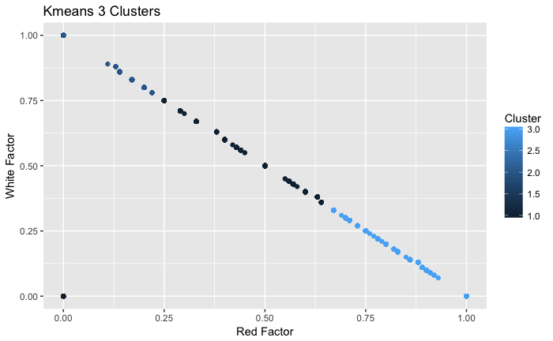

```r
ggplot(clusters3, aes(Redness, Whiteness, color = Cluster)) + geom_point() +
#scale_y_continuous(labels = percent) + scale_x_continuous(labels = percent) +
  xlab("Red Factor") +
  ylab("White Factor") +
  ggtitle("Kmeans 3 Clusters")
```

This was an investigation to see if utilizing kmeans k=5 would help resolve the voting logic we implored. However it became even more confusing than k=3.

Execute kmeans with 5 clusters (This becomes confusing however).

```r
km5 <- kmeans(RWWG, 5, iter.max = 10000)
summary(km5)
```

Create new dataframe with cluster columns.

```r
WnMg5 <- cbind.data.frame(WineMag$Description, WineMag$Variety, RWWG$`RedWhite$Redness`, RWWG$`RedWhite$Whiteness`, km5$cluster)
colnames(WnMg5) <- c("Description", "Variety", "Redness", "Whiteness", "Cluster")
```

Count by variety.

```r
WnMg.sum5 <- table(WineMag$Variety, kmRWWG$cluster)
```

```
Error in table(WineMag$Variety, kmRWWG$cluster) :
  object 'kmRWWG' not found
```

Kmeans analysis.

```r
clusters5 <- cbind.data.frame(WnMg5$Redness, WnMg5$Whiteness, WnMg5$Cluster)
colnames(clusters5) <- c("Redness", "Whiteness", "Cluster")
summary.data.frame(clusters5)
```

```
    Redness         Whiteness         Cluster
 Min.   :0.0000   Min.   :0.0000   Min.   :1.000
 1st Qu.:0.0000   1st Qu.:0.0000   1st Qu.:1.000
 Median :0.5000   Median :0.3300   Median :3.000
 Mean   :0.5135   Mean   :0.4234   Mean   :2.635
 3rd Qu.:1.0000   3rd Qu.:0.7500   3rd Qu.:4.000
 Max.   :1.0000   Max.   :1.0000   Max.   :5.000
```

Create a plot based on clustering.

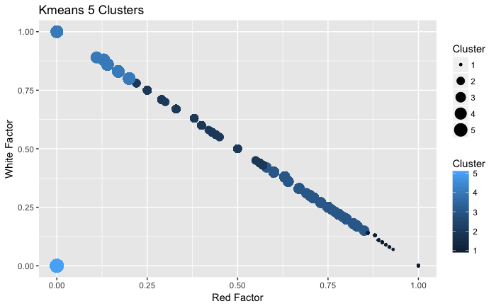

```r
ggplot(clusters5, aes(Redness, Whiteness, color = Cluster)) + geom_point(aes(size = Cluster)) +
#scale_y_continuous(labels = percent) + scale_x_continuous(labels = percent) +
  xlab("Red Factor") +
  ylab("White Factor") +
  ggtitle("Kmeans 5 Clusters")
```

Because our factors were so terribly high, we attempted to bring in regions and continents as defined by the countrycode package to help aggregate.

Load country package and library.

```r
install.packages("countrycode")
library(countrycode)
```

Find the continents for the countries.

```r
Cdf <- countrycode::countrycode(WineMag$Country, origin = "country.name", destination = "continent")
```

```
Some values were not matched unambiguously: England, US-France
Some strings were matched more than once, and therefore set to <NA> in the result: US-France,Europe,Americas
```

```r
Continents <- cbind.data.frame(WineMag$Country, Cdf)
Regiondf <- countrycode::countrycode(WineMag$Country, origin = "country.name", destination = "region")
```

```
Some values were not matched unambiguously: England, US-France
Some strings were matched more than once, and therefore set to <NA> in the result: US-France,Western Europe,Northern America
```

```r
Regions <- cbind.data.frame(WineMag$Country, Regiondf)
```

Create a table summary of the continents by country.

```r
ContinentsSummary <- table(WineMag$Country, Cdf)
ContinentsSummary
```

```
                        Cdf
                         Africa Americas  Asia Europe Oceania
  Albania                     0        0     0      1       0
  Argentina                   0     3447     0      0       0
  Australia                   0        0     0      0    3152
  Austria                     0        0     0   1959       0
  Bosnia and Herzegovina      0        0     0      3       0
  Brazil                      0       14     0      0       0
  Bulgaria                    0        0     0     56       0
  Canada                      0      149     0      0       0
  Chile                       0     3735     0      0       0
  China                       0        0     2      0       0
  Croatia                     0        0     0     70       0
  Cyprus                      0        0    15      0       0
  Czech Republic              0        0     0      6       0
  Egypt                       3        0     0      0       0
  England                     0        0     0      0       0
  France                      0        0     0  14459       0
  Georgia                     0        0    30      0       0
  Germany                     0        0     0   1529       0
  Greece                      0        0     0    541       0
  Hungary                     0        0     0    139       0
  India                       0        0     7      0       0
  Israel                      0        0   370      0       0
  Italy                       0        0     0  14850       0
  Japan                       0        0     1      0       0
  Lebanon                     0        0    27      0       0
  Lithuania                   0        0     0      4       0
  Luxembourg                  0        0     0      3       0
  Macedonia                   0        0     0     12       0
  Mexico                      0       54     0      0       0
  Moldova                     0        0     0     46       0
  Montenegro                  0        0     0      1       0
  Morocco                    11        0     0      0       0
  New Zealand                 0        0     0      0    1865
  Portugal                    0        0     0   3508       0
  Romania                     0        0     0    106       0
  Serbia                      0        0     0     10       0
  Slovakia                    0        0     0      2       0
  Slovenia                    0        0     0     72       0
  South Africa             1481        0     0      0       0
  South Korea                 0        0     2      0       0
  Spain                       0        0     0   5443       0
  Switzerland                 0        0     0      4       0
  Tunisia                     2        0     0      0       0
  Turkey                      0        0    46      0       0
  Ukraine                     0        0     0      5       0
  Uruguay                     0       52     0      0       0
  US                          0    40544     0      0       0
  US-France                   0        0     0      0       0
```

```r
RegionsSummary <- table(WineMag$Country, Regiondf)
RegionsSummary
```

```
                        Regiondf
                         Australia and New Zealand Central America Eastern Asia Eastern Europe Northern Africa Northern America
  Albania                                        0               0            0              0               0                0
  Argentina                                      0               0            0              0               0                0
  Australia                                   3152               0            0              0               0                0
  Austria                                        0               0            0              0               0                0
  Bosnia and Herzegovina                         0               0            0              0               0                0
  Brazil                                         0               0            0              0               0                0
  Bulgaria                                       0               0            0             56               0                0
  Canada                                         0               0            0              0               0              149
  Chile                                          0               0            0              0               0                0
  China                                          0               0            2              0               0                0
  Croatia                                        0               0            0              0               0                0
  Cyprus                                         0               0            0              0               0                0
  Czech Republic                                 0               0            0              6               0                0
  Egypt                                          0               0            0              0               3                0
  England                                        0               0            0              0               0                0
  France                                         0               0            0              0               0                0
  Georgia                                        0               0            0              0               0                0
  Germany                                        0               0            0              0               0                0
  Greece                                         0               0            0              0               0                0
  Hungary                                        0               0            0            139               0                0
  India                                          0               0            0              0               0                0
  Israel                                         0               0            0              0               0                0
  Italy                                          0               0            0              0               0                0
  Japan                                          0               0            1              0               0                0
  Lebanon                                        0               0            0              0               0                0
  Lithuania                                      0               0            0              0               0                0
  Luxembourg                                     0               0            0              0               0                0
  Macedonia                                      0               0            0              0               0                0
  Mexico                                         0              54            0              0               0                0
  Moldova                                        0               0            0             46               0                0
  Montenegro                                     0               0            0              0               0                0
  Morocco                                        0               0            0              0              11                0
  New Zealand                                 1865               0            0              0               0                0
  Portugal                                       0               0            0              0               0                0
  Romania                                        0               0            0            106               0                0
  Serbia                                         0               0            0              0               0                0
  Slovakia                                       0               0            0              2               0                0
  Slovenia                                       0               0            0              0               0                0
```

[output cut: 45 more lines]

```
  Portugal                             0             0               0             0            3508            0              0
  Romania                              0             0               0             0               0            0              0
  Serbia                               0             0               0             0              10            0              0
  Slovakia                             0             0               0             0               0            0              0
  Slovenia                             0             0               0             0              72            0              0
  South Africa                         0             0            1481             0               0            0              0
  South Korea                          0             0               0             0               0            0              0
  Spain                                0             0               0             0            5443            0              0
  Switzerland                          0             0               0             0               0            0              4
  Tunisia                              0             0               0             0               0            0              0
  Turkey                               0             0               0             0               0           46              0
  Ukraine                              0             0               0             0               0            0              0
  Uruguay                              0            52               0             0               0            0              0
  US                                   0             0               0             0               0            0              0
  US-France                            0             0               0             0               0            0              0
```

Create a plot of the Redness and Whiteness.

[figure not shown]

```r
ggplot(testRW, aes(RedWhite$Redness, RedWhite$Whiteness, color = WineMag$Country)) + geom_point()
```

Bring in package for minimum spanning tree.

```r
install.packages("vegan")
library(vegan)
```

Take a subset of the data.

```r
RWWG5K <- head(RWWG, 5000)
```

Create a minimum spanning tree using the test set. This killed the session.

```r
#spantree(RWWG5K, toolong = 0)
```